# TAP 02

Author

291921

```r
library(tidyverse)
library(afex)
library(BayesFactor)
library(broom)
library(car)
library(effectsize)
library(emmeans)
library(here)
library(ggfortify)
library(Hmisc)
library(knitr)
library(modelbased)
library(parameters)
library(sandwich)

# load the data here
stats_tib <- here::here("data/tap_learning_statistics.csv") %>%
  readr::read_csv() %>%
  dplyr::mutate(
    community = forcats::as_factor(community))

stats_tib <- stats_tib %>%
  dplyr::mutate(
    community = forcats::fct_relevel(community, "None", "Online", "In person")
  )
```

## **Analysis plan**

Given that performance is positively skewed, general linear model will be fitted. Statistics performance and statistics anxiety are continuous and non-negative variables. Also, community is categorical variable. Therefore, the general linear model will be used to test hypothesis. Following the hypothesis is :

- $\text{H}_1$ : Performance on the statistics assignment (stats_exam) will be predicted by statistics anxiety (stats_anxiety), but this effect will be moderated by the community to which the student was assigned (community). Specifically, the relationship between statistics anxiety and statistics performance will be weaker in (1) those assigned to a peer community (online or in person) compared to those not; (2) those assigned to an in person community compared to those assigned to an online community.
  - To test this hypothesis these variables will be entered into the model as predictors. Also, to examine the interaction between statistics anxiety and community, a factorial design will be employed.
  - A significance level of $\alpha = 0.05$ will be used as a criterion to test statistical significance.

The model to be fitted is

$$\text{Performance}_i = \hat{b}_o + \hat{b}_1\text{Statistics Anxiety}_i + \hat{b}_2\text{Community}_i + \hat{b}_3\text{Statistics Anxiety * Community}_i + e_i$$

There are several assumptions that need to be met for the general linear model. First, linearity of the model will be assumed, meaning that the relationship between the independent variables (statistics anxiety and community) and the dependent variable (performance) is linear. Second, the assumption of homoscedasticity of the residuals will be checked. This means that the variance of the residuals is constant across all values of the independent variables. This assumption will be evaluated using diagnostic plots to check whether the residuals have constant variance (homoscedasticity). Lastly, normality of the residuals will be assessed using a Q-Q plot to determine if the residuals closely follow a normal distribution, which would support the model’s assumption.

In addition, the interaction effect will be tested to determine if it is statistically significant. One variable (statistics anxiety) is continuous, and the other variable (community) is categorical. The outcome (performance) will be examined to assess whether the interaction between statistics anxiety and community influences performance, and whether the community moderates the relationship between statistics anxiety and performance.

Data will be summarized and visualized as follows :

- Means and confidence intervals of performance as the predictors (statistics anxiety and community: None, Online, In person) will be examined.
- The plot of performance as a function of statistics anxiety and community (None, Online, In person)
- Plots to assess the assumptions of the general linear model, including linearity of the model and normality and homoscedasticity of residuals.

If the assumption (normality and homoscedasticity of residuals) is violated, robust regression methods will be explained to provide more reliable estimates. Also, heteroscedasticity-consistent standard errors (HC4) will be used to ensure reliable estimates.

Effect size will be analyzed to confirm a specific influencing interaction, and a Bayesian analysis will be conducted to evaluate the strength of the main effects and interaction. While a frequentest model uses p-values to determine the significance of effects, it does not provide information about the strength of these effects. In contrast, Bayesian analysis using Bayes factors offers direct evidence of the strength of effects, and it allows the evidence to be interpreted more precisely.

## Coding

### **Summary statistics and data visualization**

```r
# descriptive the data
stats_sum <- stats_tib %>%
  dplyr::group_by(community) %>%
  dplyr::summarise(
    mean = mean(stats_exam, na.rm = TRUE),
    '95% CI lower' = mean_cl_normal(stats_exam)$ymin,
    '95% CI upper' = mean_cl_normal(stats_exam)$ymax)
stats_sum <- stats_sum %>%
  knitr::kable(digits = 2)

# visualize the data
stats_gg <- ggplot2::ggplot(stats_tib, aes(x = community, y = stats_exam,
                                           colour = community)) +
  geom_point(position = position_jitter(width=0.1),alpha = 0.2) +
  geom_violin(alpha = 0.2) +
  stat_summary(fun = mean, geom = "point", size = 2, colour = "black") +
  stat_summary(fun.data = "mean_CI_normal", geom = "pointrange",
               position = position_dodge(width = 0.5)) +
  coord_cartesian(ylim = c(0, 100)) +
  scale_y_continuous(breaks = seq(0, 100, 10)) +
  labs(x = "Type of community", y = "Grade of statistics exam(0-100)",
       colour = "Type of community") +
  theme_minimal()

stats_gg2 <- ggplot2::ggplot(stats_tib, aes(x = stats_anxiety,
                                            y = stats_exam,
                                            colour = community,
                                            fill = community)) +
  geom_point() +
  geom_smooth(method = "lm") +
  coord_cartesian(ylim = c(0, 100)) +
  scale_x_continuous(breaks = seq(0, 100, 10)) +
  scale_y_continuous(breaks = seq(0, 100, 10)) +
  labs(x = "State of statistics anxiety",
       y = "Grade of statistics exam(0-100)",
       colour = "Community", fill = "Community") +
  theme_minimal()
```

### **Statistical models**

```r
# orthogonal contrasts to set up dummy variables
none_vs_community <- c(-2/3, 1/3, 1/3)
online_vs_person <- c(0, -1/2, 1/2)
contrasts(stats_tib$community) <- cbind(none_vs_community, online_vs_person)

# fitting model(ANOVA)
stats_lm <- lm(stats_exam ~ stats_anxiety*community,
               data = stats_tib)

stats_anova <- car::Anova(stats_lm, type =3) %>%
  knitr::kable(digits = 2)

# estimated marginal means to confirm interaction
stats_mdl <- modelbased::estimate_means(stats_lm)

# parameter estimates
stats_tdy <- broom::tidy(stats_lm, conf.int = TRUE, conf.level = 0.95) %>%
  knitr::kable(digits = 2)

# simple effects analysis
stats_joint <- emmeans::joint_tests(stats_lm, "community")
```

### **Model assumptions**

```r
# diagnostic linearity of the model, homoscedasticity and normality of residuals, cook's distance
stats_auto <- ggplot2::autoplot(stats_lm,
                  which = c(1,3,2,4),
                  colour = "#bace83",
                  smooth.colour = "#fe787e",
                  alpha = 0.5,
                  size =1) +
  theme_minimal()

stats_auto1 <- ggplot2::autoplot(stats_lm,
                  which = 1,
                  colour = "#bace83",
                  smooth.colour = "#fe787e",
                  alpha = 0.5,
                  size =1) +
  theme_minimal()

stats_auto4 <- ggplot2::autoplot(stats_lm,
                  which = 4,
                  colour = "#bace83",
                  smooth.colour = "#fe787e",
                  alpha = 0.5,
                  size =1) +
  theme_minimal()

stats_auto3 <- ggplot2::autoplot(stats_lm,
                  which = 3,
                  colour = "#bace83",
                  smooth.colour = "#fe787e",
                  alpha = 0.5,
                  size =1) +
  theme_minimal()

stats_auto2 <- ggplot2::autoplot(stats_lm,
                  which = 2,
                  colour = "#bace83",
                  smooth.colour = "#fe787e",
                  alpha = 0.5,
                  size =1) +
  theme_minimal()
```

### Robust

```r
# robust model
stats_rob <- robust::lmRob(stats_exam ~
                             stats_anxiety*community,
                           data = stats_tib)
stats_rob_sum <- summary(stats_rob)

stats_mdl_prm <- parameters::model_parameters(stats_lm, vcov = "HC4") %>%
  knitr::kable(digits = 2)
```

### Effect size and Bayes factor

```r
# effect size
stats_effect <- car::Anova(stats_lm, type=3) %>%
  effectsize::omega_squared(ci = 0.95) %>%
  knitr::kable(digits = 2)

# Bayes Factor
anx_bf <- BayesFactor::lmBF(formula = stats_exam ~
                              stats_anxiety,
                            data = stats_tib)
com_bf <- BayesFactor::lmBF(formula = stats_exam ~
                              stats_anxiety + community,
                            data = stats_tib)
int_bf <- BayesFactor::lmBF(formula = stats_exam ~
                              stats_anxiety + community +
                              stats_anxiety:community,
                            data = stats_tib)
```

## **Report**

### **Summary statistics and data visualization**

```r
stats_sum
```

Table 1: Summary of group mean statistics scores by type of community

| community | mean | 95% CI lower | 95% CI upper |
| --- | --- | --- | --- |
| None | 36.98 | 35.95 | 38.01 |
| Online | 49.88 | 48.86 | 50.89 |
| In person | 63.22 | 62.31 | 64.12 |

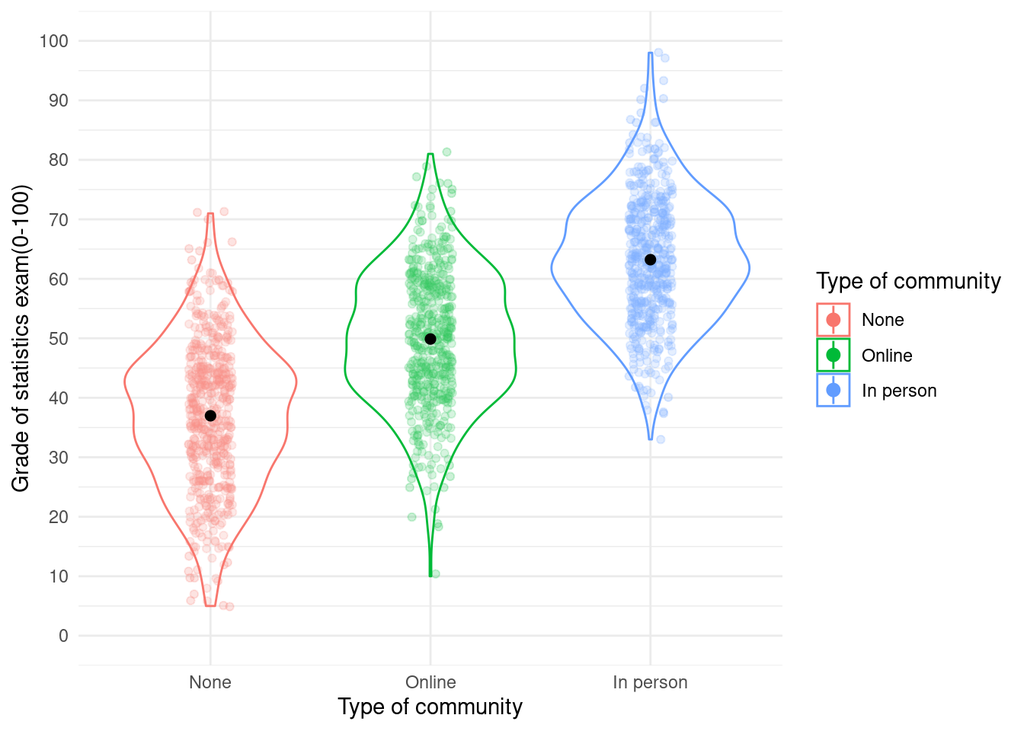

Figure 1: Plot of group mean and distribution of statistics scores by type of community

```r
stats_gg
```

This Table 1 (above) and Figure 1 (below) were shown means of performance as types of communities. Also, the confidence interval indicated that the mean of each community includes within the 95% confidence range : None (35.95, 38.01), Online (48.86, 50.89), and in person (62.31, 64.12). The estimates of the means were accurate because each confidence interval was narrow.

The differences between groups were likely significant, as the confidence intervals not overlapped. However, ANOVA is needed to confirm the significance of these differences. Overall, the students assigned peer community(online and in person) showed the better performance than the students assigned normal teaching (none).

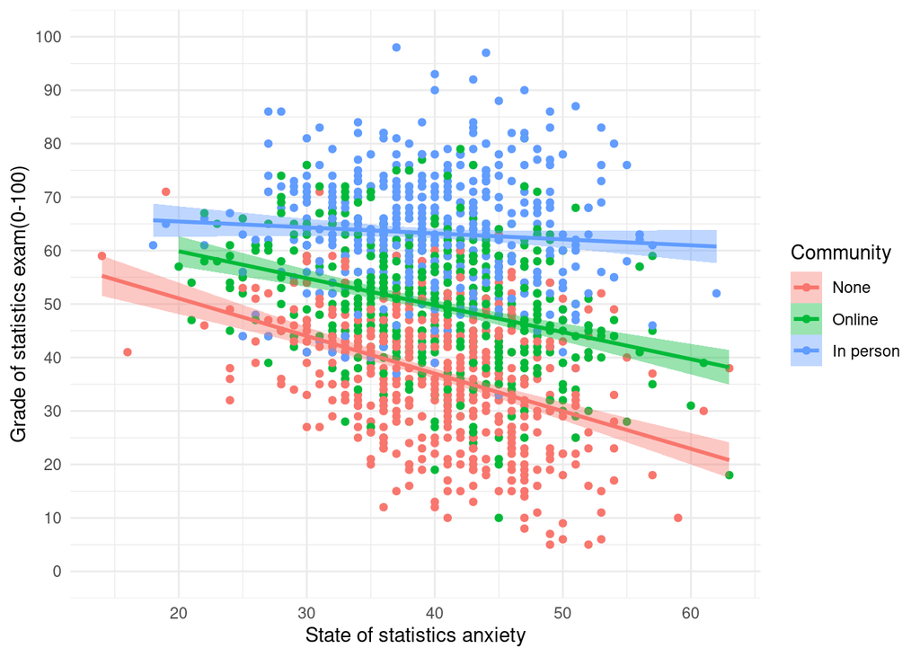

Figure 2: Distribution of statistics scores by community group according to statistics anxiety

```r
stats_gg2
```

### Model assumption

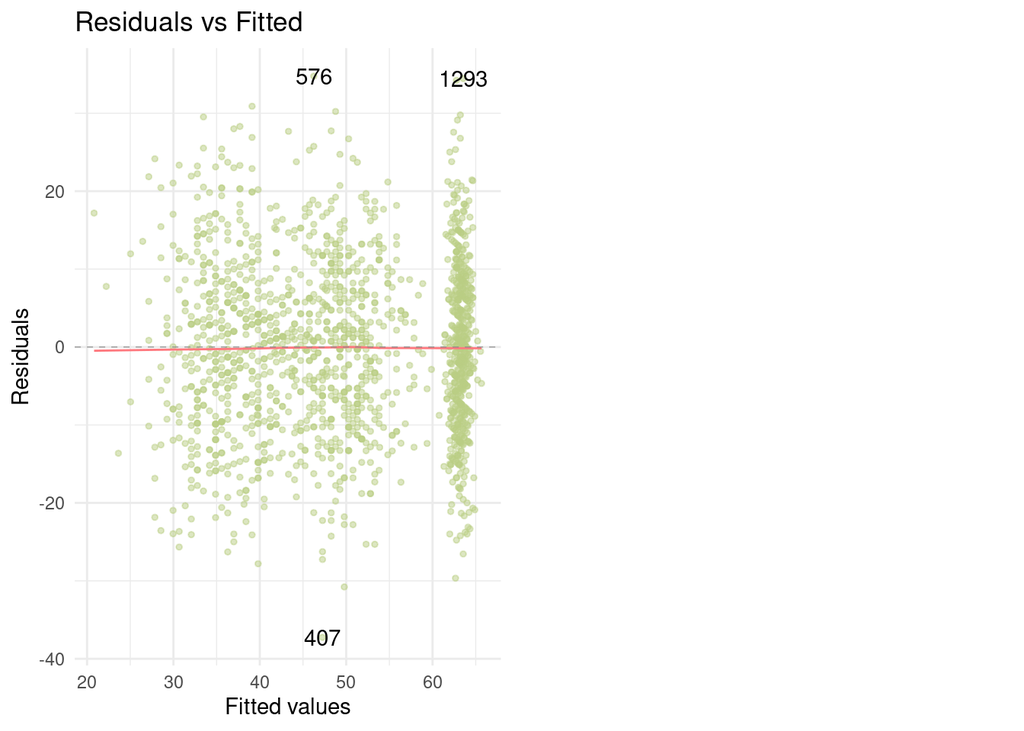

Figure 3: Plot for linearity of the model

```r
stats_auto1
```

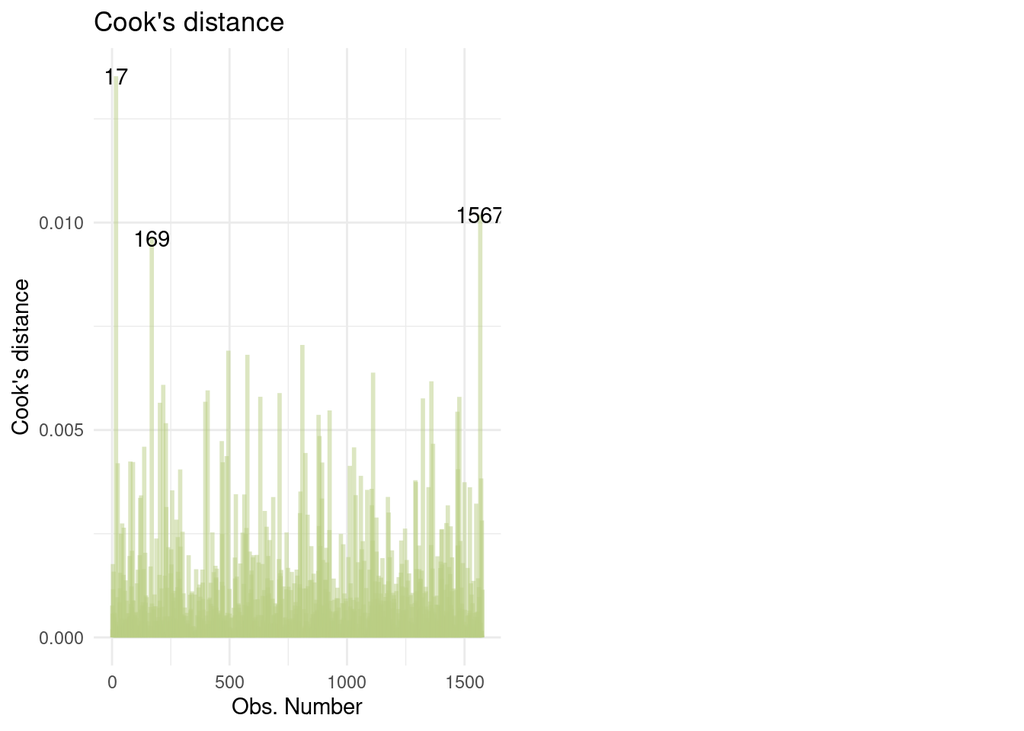

Figure 4: Plot for cook’s distance

```r
stats_auto4
```

Two figures (Figure 3 and Figure 4) were shown the linearity of the model and distribution of outliers. In Figure 3, the line (red) was flat, and the values (green) were distributed evenly. In addition, in Figure 4, there was no value over 0.02. In summary, the model could be assumed to have linearity and no considerable outliers.

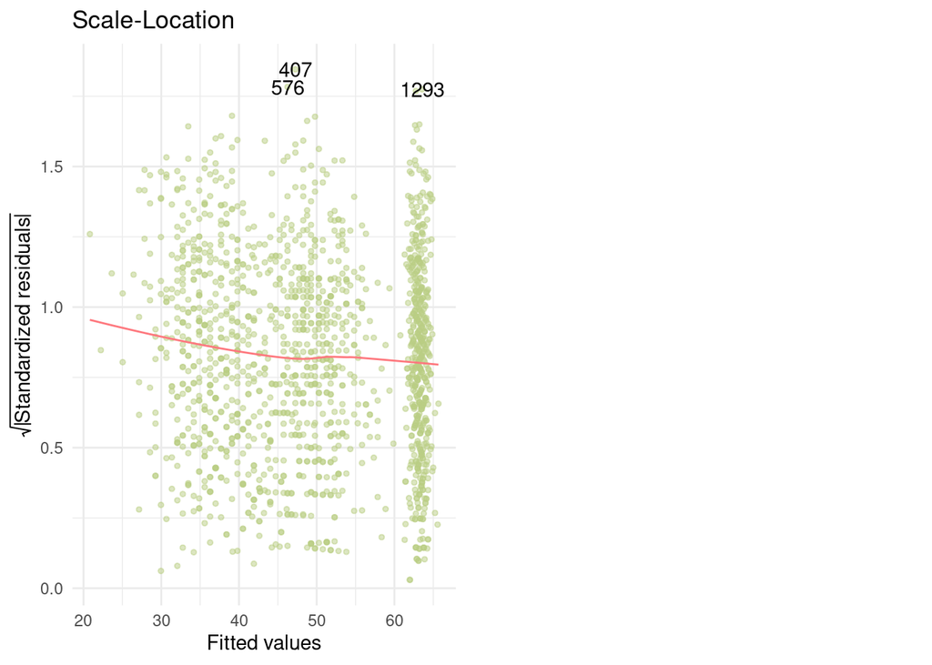

Figure 5: Plot for homoscedasticity of residuals

```r
stats_auto3
```

Figure 5 was shown homoscedasticity of residuals. However, the line (red) was not flat, so assumption of homoscedasticity was violated. In short, this was doubts about the model’s ability to predict the outcome accurately based on the given variables.

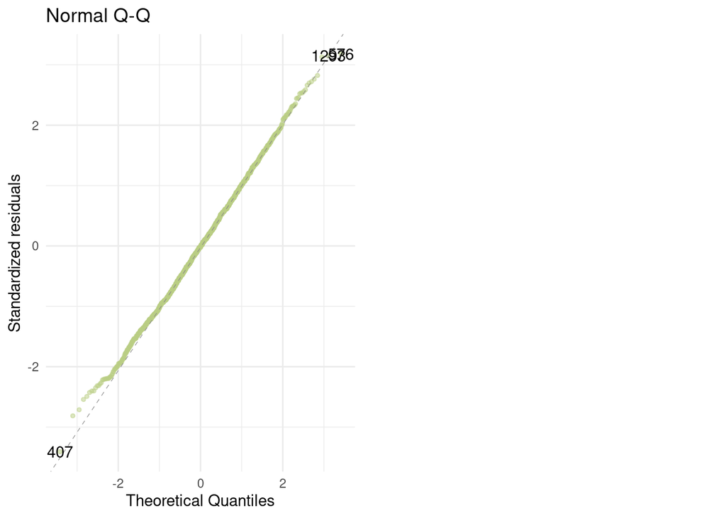

Figure 6: Plot for normality of residuals

```r
stats_auto2
```

Figure 6 was shown normality of residuals. The plot generally was shown a diagonal pattern, but some values at the ends deviated from the diagonal. This made it difficult to confidently assert that the residuals follow a normal distribution.

Based on the diagnostic plots, homoscedasticity and normality of residuals appear to be unstable, suggesting the need to apply robust regression methods.

### Statistical models

```r
stats_anova
```

Table 2: Statistics of main effect and interaction

|  | Sum Sq | Df | F value | Pr(>F) |
| --- | --- | --- | --- | --- |
| (Intercept) | 208653.49 | 1 | 1739.66 | 0.00 |
| stats_anxiety | 14516.10 | 1 | 121.03 | 0.00 |
| community | 183.15 | 2 | 0.76 | 0.47 |
| stats_anxiety:community | 4438.98 | 2 | 18.51 | 0.00 |
| Residuals | 188304.83 | 1570 | NA | NA |

Table 2 was shown a significant effect of the statistics anxiety, $F(1, 1570) = 121.03, p < 0.001.$ Also, effects of the community was not significant, $F(2, 1570) = 0.76, p = 0.47.$ However, there was a significant interaction between the statistics anxiety and community, $F(2, 1570) = 18.51, p < 0.001.$ This result suggests that the effect of statistics anxiety on the performance changes depending on the conditions of the community.

Table 3: Statistics of estimated marginal means as a type of community

```r
stats_mdl
```

```
Estimated Marginal Means

community |  Mean |   SE |         95% CI
-----------------------------------------
None      | 37.03 | 0.47 | [36.12, 37.95]
Online    | 49.81 | 0.49 | [48.84, 50.78]
In person | 63.22 | 0.48 | [62.29, 64.16]

Marginal means estimated at community
```

According to this Table 3, performance scores varied across different community groups. Specifically, performance in peer community (online and in person) was higher than those in normal teaching (none). Also, the confidence interval indicated that the estimated mean for each community include within the 95% confidence range: None (36.12, 37.95), Online (48.84, 50.78), and in person (62.29, 64.16). The estimates of the means were accurate because each confidence interval was narrow, indicating a higher level of precision in the estimates.

Moreover, performance in group of in person was higher than those in online. This indicated Statistics anxiety affects performance, and this effect is moderated by the community. Moreover, this moderation effect suggests that the in-person community is more effective than the online community.

```r
stats_tdy
```

Table 4: Statistics of estimates of the model

| term | estimate | std.error | statistic | p.value | conf.low | conf.high |
| --- | --- | --- | --- | --- | --- | --- |
| (Intercept) | 67.59 | 1.62 | 41.71 | 0.00 | 64.41 | 70.77 |
| stats_anxiety | -0.44 | 0.04 | -11.00 | 0.00 | -0.52 | -0.36 |
| communitynone_vs_community | 3.69 | 3.42 | 1.08 | 0.28 | -3.02 | 10.40 |
| communityonline_vs_person | -2.29 | 3.99 | -0.57 | 0.57 | -10.12 | 5.53 |
| stats_anxiety:communitynone_vs_community | 0.40 | 0.08 | 4.69 | 0.00 | 0.23 | 0.56 |
| stats_anxiety:communityonline_vs_person | 0.39 | 0.10 | 3.99 | 0.00 | 0.20 | 0.59 |

Table 4 was shown that the performance is predicted by each variables. First, as students experienced higher levels of statistics anxiety, their exam performance tended to decrease, $\hat{b} = -0.44 [-0.52, -0.36], t = -11.00, p < 0.001.$ Statistics anxiety increases by one unit, performance decreases by -0.44 units, and the confidence interval not included 0, indicating this main effect was significant. While a 1 unit increases in statistics anxiety may seem small, a 10 unit increases could lead to a 4.4 unit decreases in performance scores. Given the score range of 0 to 100, this value could be critical in academic performance.

The comparisons between different types of communities were not statistically significant. Specifically, there was no meaningful difference in exam scores between the ‘None’ community, $\hat{b} = 3.69 [-3.02, 10.40], t = 1.08, p = 0.281$ and the included community, nor between the ‘Online’ and ‘In-person’ communities, $\hat{b} = -2.29 [-10.12, 5.53], t = -0.58, p = 0.57.$ Also, the confidence interval included 0, indicating this effects were not significant.

However, there were significant interaction effects. The effects of statistics anxiety on exam performance was different as type of community. Specifically, learning with community (online and in person) was less decreasing on exam performance when statistics anxiety increased, $\hat{b} = 0.40 [0.23, 0.56], t = 4.69, p < 0.001.$ And group in person was less decreasing on exam performance when statistics anxiety comparing to online community, $\hat{b} = 0.39 [0.20, 0.59], t = 3.99, p < 0.001.$ These confident interval not included 0, indicating these interaction were significant. Interaction increases by one unit, performance increases by 0.40 and 0.39 respectively. Given the score range of 0 to 100, this value could be also essential in academic performance.

These effects support the hypothesis : the relationship between statistics anxiety and statistics performance was weaker in those assigned to a peer community (online or in person) compared to those not. And the moderate effects assigned in person community is more strong than those assigned to an online community.

Table 5: Statistics of community effect for statistics anxiety

```r
stats_joint
```

```
community = None:
 model term    df1  df2 F.ratio p.value
 stats_anxiety   1 1570 105.684  <.0001

community = Online:
 model term    df1  df2 F.ratio p.value
 stats_anxiety   1 1570  54.868  <.0001

community = In person:
 model term    df1  df2 F.ratio p.value
 stats_anxiety   1 1570   2.452  0.1176
```

Table 5 was shown the effect of statistics anxiety as each type of community. It revealed that statistics anxiety in normal teaching (none) had a strong negative affect on exam performance, $F(1, 1570) = 105.68, p < 0.0001.$ Also, the students’ anxiety in online community had a significant effect on exam performance, $F(1, 1570) = 54.87, p < 0.0001.$ But this value was lower than “none” community, so exam performance in this group (online) was less affected by statistics anxiety respectively. In contrast, statistics anxiety in person community not affected on exam performance, $F(1, 1570) = 2.45, p = 0.12.$ These results support that community is moderate relationship between statistics anxiety and exam performance. In other words, It can see that the community moderates the effect of statistics anxiety on performance, with the online community having a more positive moderating effect than none, and the in-person community having an even more positive effect than the online community.

Table 6: Statistics of robust regression

```r
stats_rob_sum
```

```
Call:
robust::lmRob(formula = stats_exam ~ stats_anxiety * community,
    data = stats_tib)

Residuals:
      Min        1Q    Median        3Q       Max
-37.18519  -7.66738   0.07357   7.41638  34.84337

Coefficients:
                                         Estimate Std. Error t value Pr(>|t|)
(Intercept)                              67.67896    1.72181  39.307  < 2e-16
stats_anxiety                            -0.44585    0.04250 -10.489  < 2e-16
communitynone_vs_community                4.43527    3.63441   1.220 0.222513
communityonline_vs_person                -2.34079    4.23837  -0.552 0.580831
stats_anxiety:communitynone_vs_community  0.37887    0.08962   4.227  2.5e-05
stats_anxiety:communityonline_vs_person   0.38944    0.10473   3.718 0.000208

(Intercept)                              ***
stats_anxiety                            ***
communitynone_vs_community
communityonline_vs_person
stats_anxiety:communitynone_vs_community ***
stats_anxiety:communityonline_vs_person  ***
---
Signif. codes:  0 '***' 0.001 '**' 0.01 '*' 0.05 '.' 0.1 ' ' 1

Residual standard error: 11.18 on 1570 degrees of freedom
Multiple R-Squared: 0.462

Test for Bias:
            statistic p-value
M-estimate      2.124  0.9079
LS-estimate   -18.999  1.0000
```

```r
stats_mdl_prm
```

Table 7: Statistics of robust regression estimates

| Parameter | Coefficient | SE | CI | CI_low | CI_high | t | df_error | p |
| --- | --- | --- | --- | --- | --- | --- | --- | --- |
| (Intercept) | 67.59 | 1.55 | 0.95 | 64.55 | 70.63 | 43.65 | 1570 | 0.00 |
| stats_anxiety | -0.44 | 0.04 | 0.95 | -0.52 | -0.36 | -11.24 | 1570 | 0.00 |
| communitynone_vs_community | 3.69 | 3.34 | 0.95 | -2.86 | 10.24 | 1.10 | 1570 | 0.27 |
| communityonline_vs_person | -2.29 | 3.73 | 0.95 | -9.60 | 5.02 | -0.62 | 1570 | 0.54 |
| stats_anxiety:communitynone_vs_community | 0.40 | 0.08 | 0.95 | 0.23 | 0.56 | 4.67 | 1570 | 0.00 |
| stats_anxiety:communityonline_vs_person | 0.39 | 0.09 | 0.95 | 0.21 | 0.58 | 4.19 | 1570 | 0.00 |

The assumptions of homoscedasticity and normality of residuals appeared to be unstable, so a robust model was examined. However, since the p-values were above $p > 0.05$ (Table 6), it indicated that there is no significant bias in the original model. Furthermore, the estimates from the robust model showed no substantial differences from those of the original model (Table 7), suggesting that the interpretations made from the original model was valid.

```r
stats_effect
```

Table 8: Statistics of effect size of interaction

| Parameter | Omega2_partial | CI | CI_low | CI_high |
| --- | --- | --- | --- | --- |
| stats_anxiety | 0.07 | 0.95 | 0.05 | 1 |
| community | 0.00 | 0.95 | 0.00 | 1 |
| stats_anxiety:community | 0.02 | 0.95 | 0.01 | 1 |

```r
anx_bf
```

```
Bayes factor analysis
--------------
[1] stats_anxiety : 1.616127e+12 ±0%

Against denominator:
  Intercept only
---
Bayes factor type: BFlinearModel, JZS
```

```r
com_bf/anx_bf
```

```
Bayes factor analysis
--------------
[1] stats_anxiety + community : 1.371683e+227 ±1.58%

Against denominator:
  stats_exam ~ stats_anxiety
---
Bayes factor type: BFlinearModel, JZS
```

```r
int_bf/com_bf
```

```
Bayes factor analysis
--------------
[1] stats_anxiety + community + stats_anxiety:community : 471325.9 ±3.61%

Against denominator:
  stats_exam ~ stats_anxiety + community
---
Bayes factor type: BFlinearModel, JZS
```

A Bayesian analysis was conducted to evaluate the strength of the main effects and interaction, as well as to provide evidence in support of the alternative hypothesis.

## Summary

To sum up, hypothesis was supported. Performance on the statistics assignment was predicted by statistics anxiety. However, community was moderated the relationship between performance and statistics anxiety.

Specifically, the relationship between statistics anxiety and performance was weaker in those assigned to a peer community (online or in person) compared to those not. In addition, the effect which assigned to the in person community was stronger than those assigned to the online community. In short, peer community was a protective factor that statistics anxiety affect negatively performance in statistics exam. Among them, the in person community moderated the effect the most effectively.

Contrary to concerns about the potential violation of the assumptions of homoscedasticity and normality of residuals, the robust model not revealed any bias in the original model. Additionally, the estimates showed no difference from those of the original model, confirming that the original model was fitted well.

While the effect size analysis indicated that the interaction effect was small, the Bayesian analysis suggested a very strong effect. Although there may be discrepancies regarding the strength of the interaction, considering the distribution of performance scores as community and the estimates, the Bayesian analysis implies that the interaction effect is substantial.